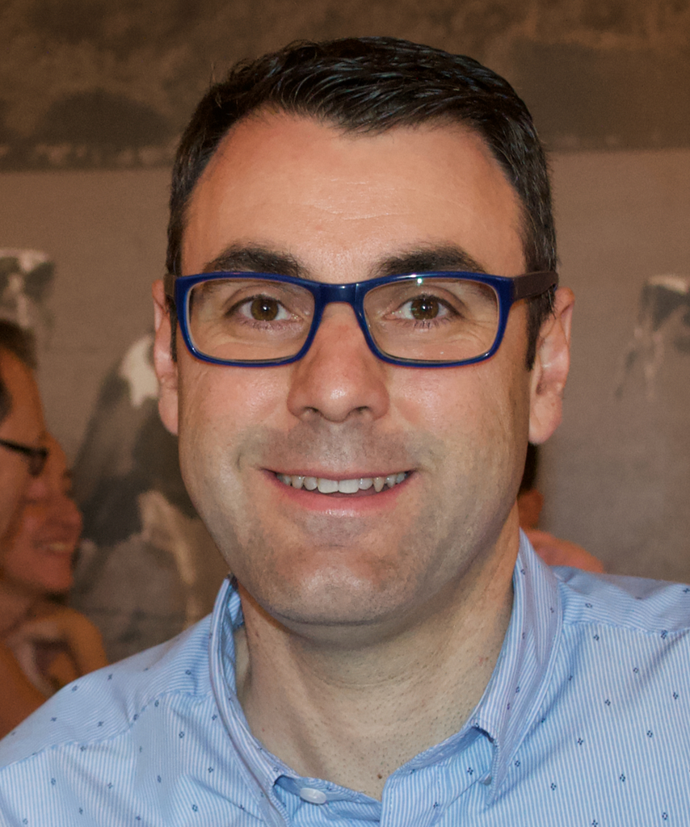

# Curriculum Vitae

## Affiliation

Full Professor  
Deputy Director at the Center of Operations Research (CIO)  
Universidad Miguel Hernández de Elche  
Avda. de la Universidad s/n  
3202 Elche (Alicante)– Spain  
Email: xbarber at umh point es

A concise overview of my academic trajectory, research activity, teaching experience and professional contributions.

Full scientific metrics:  
**Google Scholar** · https://scholar.google.es/citations?user=KUzOpI4AAAAJ  
**ORCID** · https://orcid.org/0000-0003-3079-5855

## CV Summary

**Summary**

Full Professor of Statistics at Miguel Hernández University (UMH), specialised in Bayesian modelling, Machine Learning, Artificial Intelligence and spatio-temporal statistics. Member of IMCIDIA, CIO, STATSALUT, the **Artificial Intelligence Research Group (Grupo IA – UMH)**, and VaBaR (Valencia Bayesian Research Group).

I have authored more than 80 peer-reviewed papers in statistics, AI/ML, ecology, climate sciences, epidemiology and clinical modelling. My work integrates principled Bayesian inference with modern AI/ML approaches for predictive analytics, environmental modelling, biomedical research and data-driven decision making.

## Research Interests

**Core Methodological Areas**

- AI & Machine Learning (RF, BART, boosting, XAI, LLMs)
- Bayesian hierarchical models, INLA, SPDE, latent Gaussian models
- Spatio-temporal modelling, environmental forecasting, extreme events
- Clinical and health data analytics, survival models, CDS
- DEA and data-driven frontier modelling

**Application Domains**

- Environmental & ecological systems (SDMs, aquaculture risk, climate)
- Health sciences & epidemiology (clinical prediction, digital surgery)
- Agriculture, industry & socioeconomic systems

**Research Philosophy**

Integration of rigorous Bayesian modelling with scalable AI/ML methods to produce robust, interpretable and actionable models for complex systems under uncertainty.

## Teaching Activity

**University Teaching**

Undergraduate and graduate teaching since 2005 in Statistics, Econometrics, Bayesian modelling, Data Analysis, Machine Learning, Time Series and Experimental Design.  
More than **350 ECTS** taught across UMH and UV.

**Master and Postgraduate Teaching**

Teaching in Master’s degrees in Public Health, Bioestadística, Neuropsychopharmacology, Teacher Training, Bioestadística (UV) and Computational Statistics & Data Science (UMH).

**Generative AI & Public Administration Training**

Instructor in specialised courses for public administrations in the Valencian Community on:  
- Generative AI  
- Prompt Engineering  
- LLM-based document analysis  
- AI ethics and responsible use in government workflows

## Supervision

**PhD Theses**

Supervision of doctoral theses in Bayesian modelling, environmental analytics, efficiency analysis and health sciences, and multivariate frontier estimation.

Ongoing supervision in Bayesian diagnostic modelling, and extreme-event modelling.

**Master & Undergraduate Theses**

Direction of more than **40 MSc / TFM / TFG** works across Public Health, Bioestadística, Data Science, Environmental Modelling and Clinical Analytics.

## Research Output

**Publications**

More than **80 peer-reviewed publications** in international journals (JCR/WoS/Scopus) spanning statistics, ecology, health sciences, AI/ML and environmental sciences.  
Selected publications available on Google Scholar and ORCID.

**Editorial & Reviewing Activity**

Statistical Editor of *Public Health Nutrition* (Cambridge University Press).  
Reviewer for multiple journals in statistics, AI/ML, ecology and health sciences.  
Evaluator for national and regional research agencies.

## Projects & Grants

**Research Projects**

Participation in regional, national and European research projects in Bayesian modelling, climate-risk mitigation in aquaculture, environmental analytics, health data modelling and AI applications.

Principal Investigator in climate-risk aquaculture modelling (MODESTA – ThinkInAzul).

**Collaborations**

Collaborations with hospitals, environmental agencies, research centres and industry (e.g., AVRAMAR, UMH–FISABIO STATSALUT, public health institutions).

## Technology Transfer & Professional Activity

**Applied Statistical Consulting**

Consulting in statistical modelling, machine learning, environmental analytics, clinical studies, efficiency analysis and data-driven decision systems.

**AI for Industry & Public Sector**

Development and adoption of AI/ML workflows, explainability tools, predictive systems and LLM-based automation in public administration and private organisations.

## University Service

**Academic Management**

Roles in academic management, committees, coordination and programme evaluation at UMH.

## Additional Information

**Awards & Recognition**

Multiple DOCENTIA-UMH Teaching Excellence recognitions and Talento Docente awards.

**Professional Membership**

Member of:  
- Grupo IA – Artificial Intelligence Research Group (UMH)  
- VaBaR – Valencia Bayesian Research Group  
- SEIO  
- IBS – Spanish Region

## Last Publications (Last 10 Years)

**AI, Machine Learning & Bayesian Modelling**

- **Sánchez-Guillén, L., Lozano-Quijada, C., Soler-Silva, Á., et al., Barber, X.** (2024).  
  *A calculator for musculoskeletal injuries prediction in surgeons: a machine learning approach*.  
  **Surgical Endoscopy**, 6577–6585.
- **Fuster-Alonso, A., Mestre-Tomás, J., Baez, J.C., Pennino, M.G., Barber, X., et al.** (2025).  
  *Machine learning applied to global scale species distribution models*.  
  **Scientific Reports**, 15, 37534.
- **Polotskaya, K., Muñoz-Valencia, C., Rabasa, A., Quesada-Rico, J.A., Orozco-Beltrán, D., Barber, X.** (2024).  
  *Bayesian Networks for the Diagnosis and Prognosis of Diseases: A Scoping Review*.  
  **Machine Learning and Knowledge Extraction (MAKE)**, 6(2), 1243–1262.
- **España, V.J., Aparicio, J., Barber, X.** (2025).  
  *An adaptation of Random Forest to estimate convex non-parametric production technologies: an empirical illustration in education*.  
  **International Transactions in Operational Research**, 32(5), 2523–2546.
- **España, V.J., Aparicio, J., Barber, X.** (2025).  
  *Estimating production technologies using multi-output adaptive constrained enveloping splines*.  
  **Computers & Operations Research**, 107242.
- **Esteve, M., España, V.J., Aparicio, J., Barber, X.** (2022).  
  *eat: An R Package for fitting Efficiency Analysis Trees*.  
  **The R Journal**, 14(3), 249–281.
- **España, V.J., Aparicio, J., Barber, X., Esteve, M.** (2023).  
  *Extending Multivariate Adaptive Regression Splines to estimate production functions in DEA*.  
  **European Journal of Operational Research**, 312(2), 684–699.
- **Barber, X., Conesa, D., López-Quílez, A., Martínez-Minaya, J., Paradinas, I., Pennino, M.** (2021).  
  *Incorporating biotic information in Species Distribution Models: A coregionalised Bayesian approach*.  
  **Mathematics**, 9, 417.
- **Barber, X., Conesa, D., López-Quílez, A., Morales, J.** (2019).  
  *Multivariate bioclimatic indices modelling: A coregionalised approach*.  
  **JABES**, 24(2), 225–244.
- **Martinez-García, M., Rabasa, A., Barber, X., et al.** (2021).  
  *Key factors affecting unwillingness to be confined during COVID-19*.  
  **Scientific Reports**, 11, 18626.
- **Oliver, N., Barber, X., Roomp, K., Roomp, K.** (2020).  
  *Assessing the Impact of the COVID-19 Pandemic in Spain: Online Survey Analysis*.  
  **Journal of Medical Internet Research**, 22(9), e21319.

**Environmental & Ecological Modelling**

- **Figueira, M., Barber, X., Conesa, D., López-Quílez, A., Martínez-Minaya, J., Pennino, M.** (2024).  
  *Bayesian feedback in ecological sciences*.  
  **Ecological Informatics**, 84, 102858.
- **Fernández-Gómez, L., Sánchez-Zapata, J.A., Donázar, J.A., Barber, X., Barbosa, J.M.** (2023).  
  *Ecosystem productivity drives breeding success under changing grazing pressure*.  
  **Science of the Total Environment**, 168553.
- **Carmen-Rincón, M., Sánchez-Zapata, J.A., Donázar, J.A., Barber, X., et al.** (2024).  
  *Long-term vegetation responses to climate under rewilding vs traditional grazing*.  
  **Landscape Ecology**, 39.
- **Rocha, D., Jordán, M., Barber, X., et al.** (2022).  
  *XRD fingerprinting to study burned soils*.  
  **Minerals**, 12, 1402.
- **Gomis, M.P., Pérez-Murcia, M.D., Barber, X., et al.** (2022).  
  *Palm-derived substrates for seedling production*.  
  **Agronomy**, 12, 1377.
- **Guilabert, F.J., Barber, X., Pérez-Murcia, M.D., et al.** (2021).  
  *Green waste streams: assessing co-composting scenarios*.  
  **Agronomy**, 11, 1870.

**Health Sciences & Clinical Research**

- **Fernández-Candela, A., Barber, X., López-Rodríguez-Arias, F., et al.** (2025).  
  *Early prediction of postoperative infection after cytoreductive surgery*.  
  **World Journal of Gastrointestinal Surgery**, 17(5).
- **Acosta-Mérida, M.A., Sánchez-Guillén, L., Gallego, M.Á., Barber, X., et al.** (2025).  
  *Data governance and digital surgery: challenges and opportunities*.  
  **Cirugía Española (Eng. Edition)**.
- **Soler-Silva, A., Sánchez-Guillén, L., Blanco-Antona, F., Barber, X., et al.** (2025).  
  *Predictors of complications after ileocecal resection in Crohn’s disease*.  
  **Techniques in Coloproctology**, 29, 61.
- **Quesada, J.A., López-Pineda, A., Orozco-Beltrán, D., Barber-Vallés, X., et al.** (2024).  
  *Diabetes as a cause of premature death in Spain*.  
  **Primary Care Diabetes**, 2024.
- **Sánchez-Guillén, L., Lillo-García, C., Barber, X., et al.** (2024).  
  *Telehealth acceptance: The TELECOVID study*.  
  **Updates in Surgery**, 2024.
- **Aguilar-Martínez, M.M., Sánchez-Guillén, L., Barber-Vallés, X., et al.** (2023).  
  *Long-term evaluation of fistulotomy and sphincteroplasty (FIPS)*.  
  **Diseases of the Colon & Rectum**, 27(6), 443–451.
- **Bosch-Ramírez, M., Sánchez-Guillén, L., Barber, X., et al.** (2023).  
  *PTNS for faecal incontinence: long-term outcomes*.  
  **Techniques in Coloproctology**, 27(6), 443–451.
- **Herlin, M., Sánchez, I., Esteban, J., Barber, X., et al.** (2021).  
  *Bone toxicity induced by TCDD: causal analysis*.  
  **Reproductive Toxicology**, 105, 25–43.
- **Sánchez-Guillén, L., Soriano-Irigaray, L., López-Rodríguez-Arias, F., Barber, X., et al.** (2021).  
  *Peripheral parenteral nutrition in enhanced recovery for colorectal surgery*.  
  **Journal of Clinical Medicine**, 10(16), 3647.
- **López-Rodríguez-Arias, F., Sánchez-Guillén, L., Lillo-García, C., Barber, X., et al.** (2021).  
  *Body composition & parenteral nutrition*.  
  **Nutrients**, 13(9).
- **Arroyo, A., Sánchez-Guillén, L., Parra, P.A., García-Catalá, L., Peña-Ros, E., Barber, X., et al.** (2020).  
  *Photodynamic therapy for complex anal fistula*.  
  **Lasers in Surgery and Medicine**, 52, 503–508.
- **Senabre-Gallego, J.M., Rosas, J., Marco-Mingot, M., García-Gómez, J.A., Barber-Vallés, X., et al.** (2019).  
  *Monitoring serum adalimumab in axial spondyloarthritis*.  
  **Rheumatology International**, 39(5), 841–849.